# Using functions with Data

Naomi Tague

January, 2020

# Random Numbers as Inputs

- sample from distributions (normal, uniform, poisson), which distribution depends on the model
- R has many tools for generating samples from distributions with known parameters (such as mean, standard deviation, or min/max)
  - generating rainfall for a hydrologic model given know mean and variance of rainfall
- R also has tools for picking samples from collections
  - generating fish catches based on populations for an economic model

## Steps for running your model over multiple inputs

1. design a data structure to store results: sometimes this is automatic but not always
2. generate the input data
3. apply to the model

# Code

```r
#' Power Required by Speed
#'
#' This function determines the power required to keep a vehicle moving at
#' a given speed
#' @param cdrag coefficient due to drag default=0.3
#' @param crolling coefficient due to rolling/friction default=0.015
#' @param v vehicle speed (m/s)
#' @param m vehicle mass (kg)
#' @param A area of front of vehicle (m2)
#' @param g acceleration due to gravity (m/s) default=9.8
#' @param pair (kg/m3) default =1.2
#' @return power (W)

autopower = function(V, m, A, cdrag=0.3, crolling=0.015,pair=1.2,g=9.8) {
  P = crolling*m*g*V + 1/2*A*pair*cdrag*V**3
  return(P)
}
```

# Sampling from Collections to Generate Data

Lets **scale** up from a single car to a group of cars on a highway and use our **autopower** function to estimate a distribution of power

What might vary?

# Our highway

3 car types

Imagine with have 3 different car types - and we know how often each occurs:

- car A mass 31000 kg, area 25 m<sup>2</sup>
- car B mass 45000 kg, area 30 m<sup>2</sup>
- car C mass 38000 kg area 22 m<sup>2</sup>

Mean highway speed is 100 km/hr

40% of cars are A, 40% of cars are B and 20% are C

```r
# generate a structure to store info on our possible cars
possible_cars = data.frame(name = c("A","B","C"),mass=c(31000,45000,38000), area = c(25,30,22))

# first look at how results vary for mean speed say 100km/hr
# do conversion
speed_base = 100 * 0.28

speed_base2 <- 80 * 0.28

# because I have one mass and area for each car and only 1 speed
# I can estimate power for each car type
# add to the data structure
possible_cars$power = autopower(V=speed_base, A = possible_cars$area, m=possible_cars$area)

head(possible_cars)
```

```
##   name  mass area     power
## 1    A 31000   25  98886.90
## 2    B 45000   30 118664.28
## 3    C 38000   22  87020.47
```

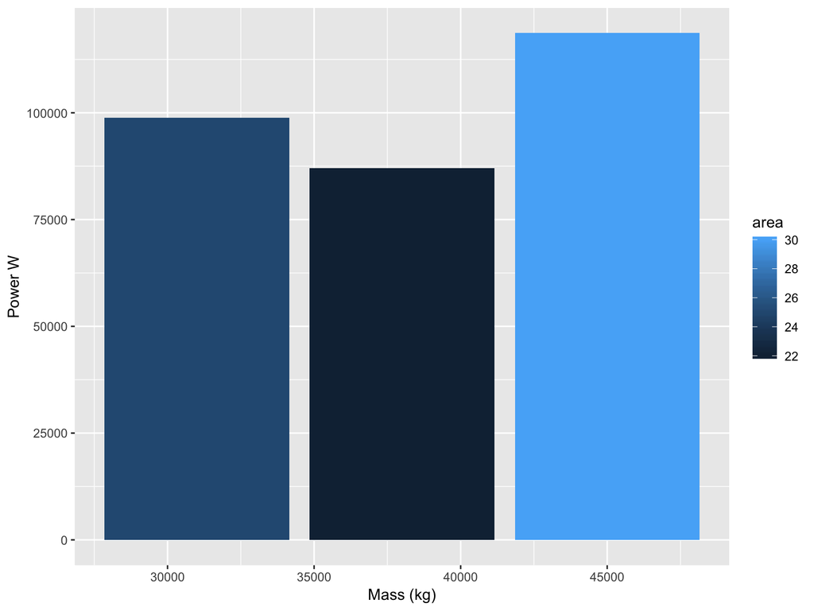

```r
# show results
ggplot(possible_cars, aes(x=mass, y=power, fill=area))+geom_col()+labs(y="Power W", x="Mass (kg)")
```

# Building our highway

What could be the total power consummed if there are 100 cars on this highway each hour, they are not all travelling at 100km/hr - but that is the average (and speeds tend to be normally distributed)

How could we take into account probbility of a given car? AND distribution of speeds?

We will use sample here

```r
# what is I want to estimate average power use given different probabilities of particular cars

# define probablity, must sum to 1 ?
# why
possible_cars$prob = c(0.4, 0.4, 0.2)

possible_cars
```

```
##   name  mass area     power prob
## 1    A 31000   25  98886.90  0.4
## 2    B 45000   30 118664.28  0.4
## 3    C 38000   22  87020.47  0.2
```

```r
# use sample to generate test cases
# first generate our data structure
# assume log normal distribution of speeds with mean 100km/hr
# recall our function needs spped in m/s not km/hr

nsample = 100
mean_speed = log(100*0.277)

speeds = rlnorm(mean=mean_speed, sd=0.1*mean_speed, nsample)
summary(speeds)
```

```
##    Min. 1st Qu.  Median    Mean 3rd Qu.    Max.
##   10.81   22.20   27.87   29.39   35.20   62.43
```

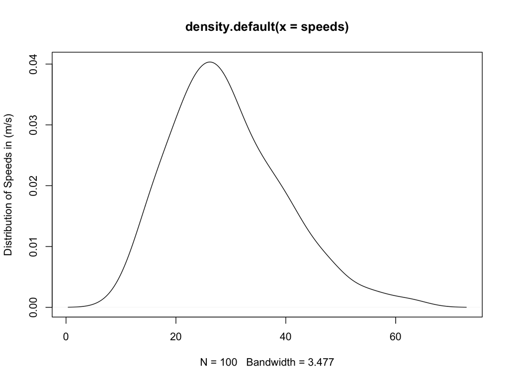

```r
plot(density(speeds), ylab="Distribution of Speeds in (m/s)")
```

```r
# create a new data frame to store results from sampling
results = data.frame(speed=speeds, power=NA)


# for each speed guess which car
# use sample
# why base?
# give each car type an id

possible_cars$row = seq(from=1, to=nrow(possible_cars))
whichcar = base::sample(possible_cars$row, size=nsample, prob=possible_cars$prob, replace=TRUE)

# what is whichcar?
head(whichcar)
```

```
## [1] 1 3 2 2 1 3
```

```r
possible_cars[whichcar,]
```

[output not shown]

[output cut: 46 more lines]

```
## 2.36    B 45000   30 118664.28  0.4   2
## 2.37    B 45000   30 118664.28  0.4   2
## 3.17    C 38000   22  87020.47  0.2   3
## 1.32    A 31000   25  98886.90  0.4   1
## 3.18    C 38000   22  87020.47  0.2   3
## 1.33    A 31000   25  98886.90  0.4   1
## 1.34    A 31000   25  98886.90  0.4   1
## 1.35    A 31000   25  98886.90  0.4   1
## 1.36    A 31000   25  98886.90  0.4   1
## 2.38    B 45000   30 118664.28  0.4   2
## 2.39    B 45000   30 118664.28  0.4   2
## 1.37    A 31000   25  98886.90  0.4   1
## 2.40    B 45000   30 118664.28  0.4   2
## 3.19    C 38000   22  87020.47  0.2   3
## 2.41    B 45000   30 118664.28  0.4   2
```

```r
# add a car to the our data structure that contains speeds
results$mass = possible_cars$mass[whichcar]

head(results)
```

```
##      speed power  mass
## 1 27.41109    NA 31000
## 2 41.52827    NA 38000
## 3 20.46476    NA 45000
## 4 21.37523    NA 45000
## 5 28.43652    NA 31000
## 6 22.33614    NA 38000
```

```r
#  add the area
results$area = possible_cars$area[whichcar]

# now lets get power for all of our samples of speed and car type
results$power = autopower(A=results$area, V=results$speed, m=results$mass)

summary(results$power)
```

```
##    Min. 1st Qu.  Median    Mean 3rd Qu.    Max.
##   54948  169594  258796  335828  409781 1379645
```

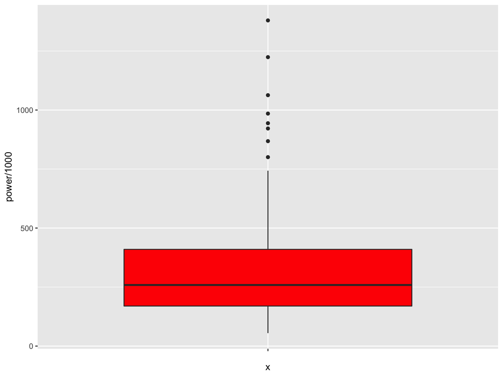

```r
ggplot(results,aes(x="", y=power/1000))+geom_boxplot(fill="red")+labs("Power kW")
```

```r
# try adding an additional car type - with mass 30000 and area 10

# what if we use more samples (200); how do estimates of mean power change
```

# Exploring multiple dimensions at once

We might also want to compute for a range of drag coefficients

This gets a bit more complicated - what if we want to look at our samples of different cars for EACH drag coefficient

# Loops

Available in all progamming language A type of “flow control” - flow from on instruction to the next

- For
- While
- If/else

In R, *apply* family often replaces loops (although traditional loops also available)

# Use sapply

We also take advantage of a *sapply* function definition that allows use to run multiple steps for each value in the sequence

Syntax is sapply(sequence, function, parameters)

OR to define a couple of steps on the fly

sapply(sequence, function(parms) {definition})

See example below

```r
# create a sequence of drag efficienies
cdrag = seq(from=0.3, to=0.5, by=0.05)
length(cdrag)
```

```
## [1] 5
```

```r
# use sapply to run for each value of cdrag, for car with area=50, mass=2000 and speed 80m/s
sapply(cdrag, autopower, A=50, V=80, m=2000)
```

```
## [1] 4631520 5399520 6167520 6935520 7703520
```

```r
cdrag
```

```
## [1] 0.30 0.35 0.40 0.45 0.50
```

```r
# now lets do this for our highway
View(results)
```

[output not shown]

```r
res = sapply(cdrag,  autopower, A=results$area, V=results$speed, m=results$mass)

# we needed a new data structure
# can you guess what is in this data structure - what are columns and what are rows
head(res)
```

```
##          [,1]     [,2]     [,3]     [,4]     [,5]
## [1,] 217593.5 233040.3 248487.2 263934.0 279380.9
## [2,] 515590.2 562859.1 610128.0 657396.9 704665.8
## [3,] 181656.6 189370.3 197084.0 204797.7 212511.4
## [4,] 194135.4 202925.2 211714.9 220504.6 229294.3
## [5,] 233061.7 250307.8 267553.9 284800.0 302046.1
## [6,] 168898.2 176253.0 183607.7 190962.5 198317.2
```

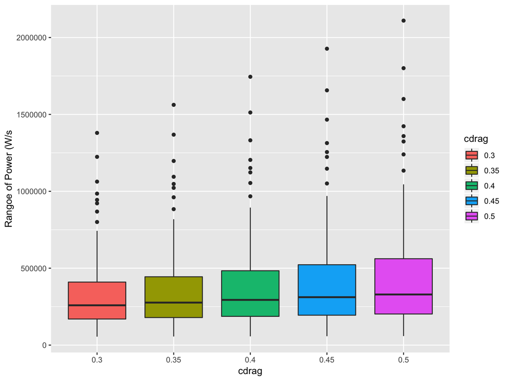

```r
# rearrange to plot - common way to get data into a form that works with ggplot
colnames(res)=cdrag
resl=as.data.frame(res) %>% gather(cdrag, power)
ggplot(resl, aes(cdrag, power, fill=cdrag))+geom_boxplot() + labs(y="Rangoe of Power (W/s", "Drag Coefficient")
```

```r
# what if we design new highways that have lower rolling coefficients
#  we can reduce the rolling coefficient by 50%
# or we can reduce the mean speed to 80 km/h (still with 10% standard deviation)
# calculate mean power for both (assuming the same car probabilities above)
# which is better
```

# What we’ve learned so far

- how to make a function
- how to generate data for a function
  - by sampling from know distributions (e.g normal)
  - sampling from a sequence with assigned probablities
- how to repeat our function for multiple parameter values
- how to create data structures to store the output of multiple uses of the function

# A bit more on Looping <>

Loops - similar to apply but more general

```r
# repeat statement
a=0
for (i in 1:5) {
 a = a+i
}
a
```

```
## [1] 15
```

```r
# find the maximum speed
speeds = runif(min=0, max=100, n=300)

maxspeed=0
for ( i  in 1:length(speeds)) {
  maxspeed = ifelse(speeds[i] > maxspeed, speeds[i], maxspeed)
}

maxspeed
```

```
## [1] 99.85247
```

```r
max(speeds)
```

```
## [1] 99.85247
```

```r
head(results)
```

```
##      speed    power  mass area
## 1 27.41109 217593.5 31000   25
## 2 41.52827 515590.2 38000   22
## 3 20.46476 181656.6 45000   30
## 4 21.37523 194135.4 45000   30
## 5 28.43652 233061.7 31000   25
## 6 22.33614 168898.2 38000   22
```

```r
# apply's are R's internal loops - FAST
# by column
results_means = apply(results, 2, mean)
# by row
silly = apply(results,1,mean)

# make a for loop to compute results_means
```

# Loops can be “nested” on loop in side the other

Exampe: Calculate NPV or a range of different interest rates and a range of damages that may be incurred 10 years in the future

Steps

- define inputs (interest rates, damages)
- define output (NPV)
- write the function
- create a data structure to store results where we vary both interest rates and damages
- use nested for loops to fill in the data structure

Try it first…

[output not shown]

[output not shown]

[output not shown]

```
##   V1 V2 V3 V4 V5 V6 V7
## 1 NA NA NA NA NA NA NA
## 2 NA NA NA NA NA NA NA
## 3 NA NA NA NA NA NA NA
## 4 NA NA NA NA NA NA NA
```

```
##    0.01 0.015 0.02 0.025 0.03 0.035 0.04
## 25   NA    NA   NA    NA   NA    NA   NA
## 33   NA    NA   NA    NA   NA    NA   NA
## 91   NA    NA   NA    NA   NA    NA   NA
## 24   NA    NA   NA    NA   NA    NA   NA
```

```
##     dis npv
## 1  0.01  NA
## 2  0.01  NA
## 3  0.01  NA
## 4  0.01  NA
## 5 0.015  NA
## 6 0.015  NA
```

[figure not shown]

[figure not shown]

# Some other types of loops

- while useful for repeating until a condition is met

Example if a metal toxin in a lake increases by 1% per year, how many years will it take for the metal level to be greater than 30 units, if toxin is current at 5 units

```r
# accumulate pollutant until a threshold - how many years does it take

# initial conditions
yr=1
pollutant_level = 5

# loop
while (pollutant_level < 30)   {
  # increase pollutant
pollutant_level = pollutant_level + 0.01* pollutant_level
# keep track of time
yr = yr + 1
}

pollutant_level
```

```
## [1] 30.2788
```

```r
yr
```

```
## [1] 182
```

```r
# while loop dangers
```

# Data types

All programing languages use data-types, or structures to hold information

- integer
- floating point/ real / numeric
- character
- string

Often data types are multi-dimensional Some useful ones in R

- vector
- matrix
- data frame
- tibble
- factors
- lists

Good data structures are

- as simple as possible
- easy to understand (readable names)
- easy to manipulate
- easy to visualize